# The relationship between political affiliation and attitude towards environmental spending in the US: evidence from the GSS

April 17, 2015

### Introduction:

In this study, we investigate the relationship between political party affiliation and attitude towards environmental spending in the US. We use data from the General Social Survey (GSS) which is considered an ideal instrument for the examination of societal attitudes and stances in combination with demographic and behavioral characteristics. The survey is conducted since 1972 and is directed to US citizens of age 18 and above. Since 1994, it is carried out every other year.

We focus our analysis in the period 2008-2012, which includes responses from the 2008, 2010 and 2012 surveys.

Detailed information on the GSS can be found in the Survey’s site at http://www3.norc.org/GSS+Website

### Data:

The data were downloaded in .Rdata format from http://bit.ly/dasi_gss_data (cumulative GSS data 1972-2012, extracted and modified by Duke University).

The detailed information for the variables (GSS Codebook) was downloaded from https://d396qusza40orc.cloudfront.net/statistics%2Fproject%2Fgss1.html

The variables of interest are:

- PARTYID: political party affiliation (“*Generally speaking, do you usually think of yourself as a Republican, Democrat, Independent, or what?*”)

and

- NATENVIR: Attitude towards national spending for improving and protecting environment (“*…I’d like you to tell me whether you think we’re spending too much money on it, too little money, or about the right amount:*”)

Both variables are categorical. Their values and labels are shown below.

**PARTYID**

| Value | Label |
| --- | --- |
| 0 | STRONG DEMOCRAT |
| 1 | NOT STR DEMOCRAT |
| 2 | IND,NEAR DEM |
| 3 | INDEPENDENT |
| 4 | IND,NEAR REP |
| 5 | NOT STR REPUBLICAN |
| 6 | STRONG REPUBLICAN |
| 7 | OTHER PARTY |
| NA | DK |
| NA | NA |

**NATENVIR**

| Value | Label |
| --- | --- |
| NA | IAP |
| 1 | TOO LITTLE |
| 2 | ABOUT RIGHT |
| 3 | TOO MUCH |
| NA | DK |
| NA | NA |

The first step was to extract these variables and take the subset of cases since 2008. Cases that had at least one missing value in these variables were excluded.

```r
partyid <- gss$partyid[ gss$year >= 2008 ]
natenvir <- gss$natenvir[ gss$year >= 2008 ]
inc <- complete.cases( partyid, natenvir )
rm( gss )

partyid <- partyid[ inc ]
natenvir <- natenvir[ inc ]
```

The result was 2908 cases. Each case is a respondent.

```r
length( partyid )
```

```
## [1] 2908
```

The following table verifies that the missing values have indeed been removed.

```r
table( partyid, natenvir, useNA = "always" )
```

```
##                     natenvir
## partyid              Too Little About Right Too Much <NA>
##   Strong Democrat           372         127       20    0
##   Not Str Democrat          337         133       28    0
##   Ind,Near Dem              283          92       16    0
##   Independent               313         149       48    0
##   Ind,Near Rep              113          83       54    0
##   Not Str Republican        218         126       56    0
##   Strong Republican          94         111       70    0
##   Other Party                36          14       15    0
##   <NA>                        0           0        0    0
```

For reasons of simplicity and clarity, we decided to merge some levels in variable partyid, i.e. the political affiliation. In particular:

- Both strong and not strong Democrats were included in a category “Democrat”
- All Independents, regardless of closeness to Democrats or Republicans were put in a new category “Independent”
- Both strong and not strong Republicans were included in a category “Republican”

A new factor variable partyid.2 was created accordingly:

```r
partyid.2 <- ifelse( partyid == "Strong Democrat" |
                     partyid == "Not Str Democrat", 1,
             ifelse( partyid == "Ind,Near Dem" |
                     partyid == "Independent" |
                     partyid == "Ind,Near Rep", 2,
             ifelse( partyid == "Not Str Republican" |
                     partyid == "Strong Republican", 3,
             ifelse( partyid == "Other Party", 4, 5 ))))

partyid.2 <- as.factor( partyid.2 )
levels( partyid.2 ) <- c( "Democrat", "Independent", "Republican", "Other" )
```

The correspondence between the old and new values in the political affiliation variable is verified below:

```r
table( partyid.2, partyid, useNA = "ifany" )
```

```
##              partyid
## partyid.2     Strong Democrat Not Str Democrat Ind,Near Dem Independent
##   Democrat                519              498            0           0
##   Independent               0                0          391         510
##   Republican                0                0            0           0
##   Other                     0                0            0           0
##              partyid
## partyid.2     Ind,Near Rep Not Str Republican Strong Republican
##   Democrat               0                  0                 0
##   Independent          250                  0                 0
##   Republican             0                400               275
##   Other                  0                  0                 0
##              partyid
## partyid.2     Other Party
##   Democrat              0
##   Independent           0
##   Republican            0
##   Other                65
```

We also decided to exclude “Other” from the analysis, again for reasons of clarity. This category does not include respondents of a certain profile and besides, it is not large.

```r
inc <- ( partyid.2 != "Other" )
partyid.2 <- partyid.2[ inc ]
natenvir <- natenvir[ inc ]

partyid.2 <- factor( partyid.2 )
addmargins( table( partyid.2 ) )
```

```
## partyid.2
##    Democrat Independent  Republican         Sum
##        1017        1151         675        2843
```

```r
addmargins( table( natenvir ) )
```

```
## natenvir
##  Too Little About Right    Too Much         Sum
##        1730         821         292        2843
```

As shown in the above distributions, the cases were reduced to 2843 after this exclusion.

### Exploratory data analysis:

The following tables show the cross-tabulation of the two variables, partyid.2 and natenvir, in counts and proportions. A mosaic plot is also presented.

```r
tab <- table( partyid.2, natenvir )
addmargins( tab )
```

```
##              natenvir
## partyid.2     Too Little About Right Too Much  Sum
##   Democrat           709         260       48 1017
##   Independent        709         324      118 1151
##   Republican         312         237      126  675
##   Sum               1730         821      292 2843
```

```r
prop <- prop.table( tab, 2 )
addmargins( prop, margin = c(1) )
```

```
##              natenvir
## partyid.2     Too Little About Right  Too Much
##   Democrat     0.4098266   0.3166870 0.1643836
##   Independent  0.4098266   0.3946407 0.4041096
##   Republican   0.1803468   0.2886724 0.4315068
##   Sum          1.0000000   1.0000000 1.0000000
```

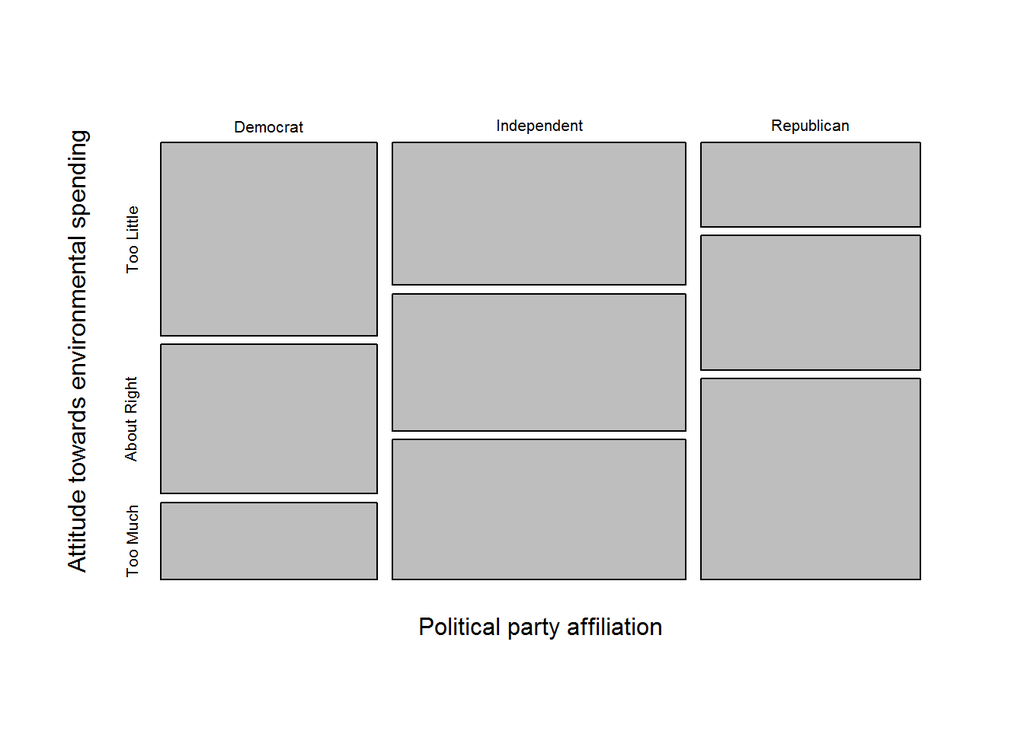

```r
plot( prop, main = "", xlab = "Political party affiliation", ylab = "Attitude towards environmental spending")
```

In the above, there seems to be an association between political party affiliation and attitude towards environmental spending. In fact, an interesting symmetry is observed. While the distribution of “about right” responses is almost uniform among the 3 parties, “too little” appears slightly less than 82% in Democrats and Independents and “too much” is more than 83% observed in Independents and Republicans. The lowest proportions in “too little” and “too much” are seen in Republicans and Democrats, 18% and 16% respectively.

This exploratory analysis, together with evidence from the literature (see for example Lawrence, C. Hamilton, L.C., and Saito, K. (2015) “A four-party view of US environmental concern”, *Environmental Politics* 24(2), pp.212?227) justifies the testing of the hypothesis that the two variables are dependent. It is quite reasonable to think that the degree of conservatism and skepticism, as reflected in political stance, is correlated with the attitude towards environmental matters.

Of course, we are not going to suggest causality. The GSS is an observational study, like all large-scale surveys, and not an experimental setup. There are no procedures for controlling for many confounding variables.

### Inference:

The proper test for independence of variables partyid.2 and natenvir is the X<sup>2</sup> one. The necessary conditions are fulfilled. Indeed, the respondents have been selected randomly and each cell in the cross-tabulation contains many more than 5 expected observations (as is evident from the row and column totals shown in the previous section).

- The null hypothesis (H0) is that natenvir is independent of partyid.2.
- The alternative hypothesis (HA) is that natenvir and partyid.2 are dependent, that is, the observed counts in the cross-tabulation of the two variables differ significantly from the expected ones.

The X<sup>2</sup> test is easily carried out in R:

```r
chisq.test( x = partyid.2, y = natenvir )
```

```
##
##  Pearson's Chi-squared test
##
## data:  partyid.2 and natenvir
## X-squared = 126.97, df = 4, p-value < 2.2e-16
```

It can be seen that the p-value is extremely small. Therefore, we can safely reject the null hypothesis even at very low significant levels. We are much confident that the two variables, political party affiliation and attitude towards environmental spending are indeed dependent.

The sampling design and the sample size seem adequate for generalization of the results of the analysis. Potential problems for generalization would appear if the sample were not representative of the population, due to non-response, over- and under-sampling of certain groups etc. But the design of the GSS eliminates such problems.

The main reference for this design is Appendix A: Sampling Design and Weights of the GSS Codebook, at http://publicdata.norc.org:41000/gss/documents//BOOK/GSS_Codebook_AppendixA.pdf

### Conclusion:

In this study, we tested the hypothesis that attitude towards environmental spending and political party affiliation are dependent, using GSS data from the 2008, 2010 and 2012 surveys.

An exploratory analysis revealed large differences. Importantly, the extreme attitudes towards environmental spending differ much between Democrats and Republicans.

The dependency of the two variables was verified with a X<sup>2</sup> test which produced an extremely small p-value.